# Onefootball x Betway

A user survey on betting

Konstantin Escher

2020-04-20

[figure not shown]

# Introduction

This project was executed by the User Research Team in collaboration with *Vincent Schalk* and *Tom Müller* from the Sales Department. For one of our major clients *Betway* we ran an exclusive user survey in 3 markets between January and March 2020. The survey is part of a contractual agreement between both parties. This document contains a summary of the execution and the respective data analysis.

# Participant Demographics

This survey was conducted in Germany, the UK and Spain, upon Betway’s request. No further selection has been made before sending out the survey. We targeted people in the given markets who speak the country’s native language (German in Germany, etc.).

## Age distribution

Due to the betting topic in which these surveys act, we agreed to focus on all Onefootball users older than 18 years old.

**Learning:** The largest group of participants is the “18-24” age group. UK is the youngest market of the three. A quarter of participants in Germany qualify as 55 years or older.

| market | 18-24 | 25-29 | 30-34 | 35-39 | 40-44 | 45-49 | 50-54 | 55+ |
| --- | --- | --- | --- | --- | --- | --- | --- | --- |
| Germany | 32.64% | 8.03% | 6.16% | 6.2% | 6.21% | 6.69% | 9.78% | 24.3% |
| Spain | 55.36% | 6.33% | 4.59% | 4.26% | 5.23% | 5.65% | 5.29% | 13.29% |
| UK | 57.12% | 8.14% | 4.86% | 4.36% | 4.22% | 4.2% | 4.05% | 13.06% |

## Gender distribution

As expected, the sample contained mainly male participants, with around 90% share per market. Some participants chose neither, therefore we see the missing percent when adding the two values together.

| market | Male | Female |
| --- | --- | --- |
| Germany | 89.31% | 9.35% |
| Spain | 90.09% | 6.4% |
| UK | 91.56% | 5.29% |

## Frequency of betting

In the next question, Betway was interested in asking our users *Who bets online at least once per month?* The following table shows the frequency of betting, split by market.

**Learning:** While observing that the majority of participants has never placed a bet before, Germany (20%), Spain (20%) and the UK (25%) have a significant share of active betters. Comparing this to the Onefootball user survey from December 2018, the number of people in Germany who never placed a bet has decreased from 73% to 58%.

| market | every day | every few days | once a week | once a fortnight | once a month | less | never |
| --- | --- | --- | --- | --- | --- | --- | --- |
| Germany | 7.37% | 4.29% | 3.67% | 2.1% | 3.05% | 21.8% | 57.71% |
| Spain | 7.3% | 3.76% | 4.53% | 1.76% | 2.57% | 16.91% | 63.18% |
| UK | 6.41% | 4.66% | 6.89% | 3.29% | 4.01% | 25.22% | 49.52% |

## Resons for not betting

Those who said they never bet, we asked what is the main reason. For all three markets, there is three main reasons for not betting: Risk aversion (scared of developing an addiction, and risk of losing money), but interestingly, especially in Germany, betting is also not perceived as an entertaining activity.

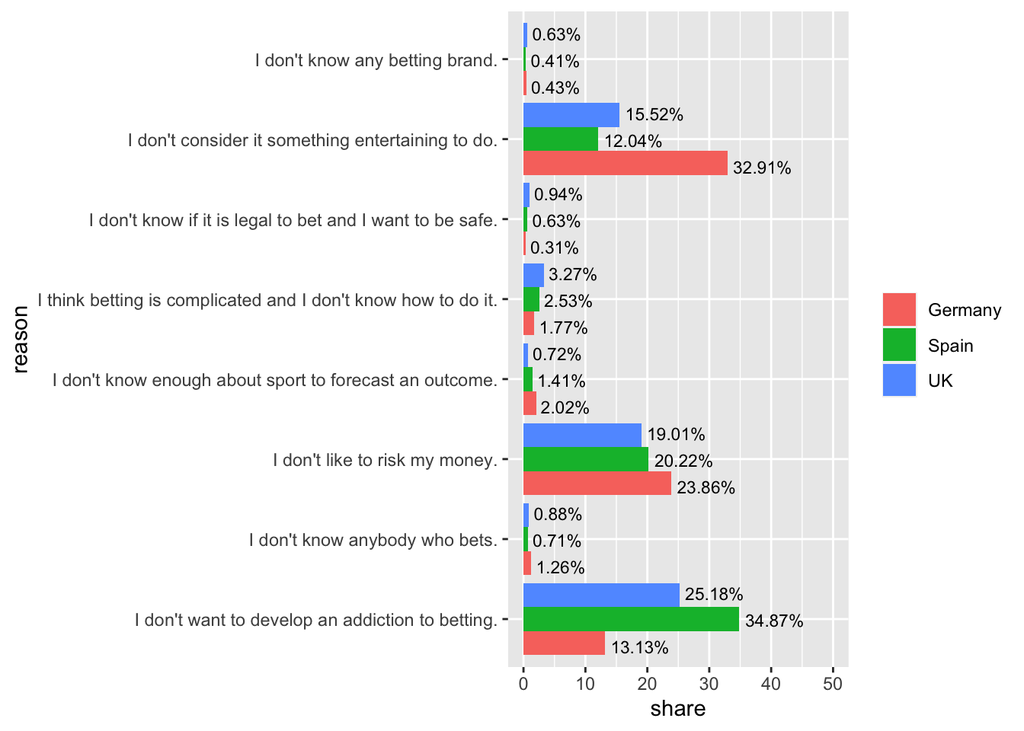

## Reduction of sample

For the core part of the survey, we only include those users, who said to bet at least *once per month.* These participants will remain for further analysis. Due to the applied logics and length of the survey, we observed a continuous decrease in sample size, meaning later questions were answered by fewer people than earlier questions.

| market | Sample Size |
| --- | --- |
| Germany | 1937 |
| Spain | 884 |
| UK | 1935 |

## Money spent on betting

This section of the survey shows how much money people spend on sports betting in an average month.

**Learnings:** We can see that the *median* is a more suitable parameter to determine the monthly amount of money spent. A small share of participants has entered amounts up to 1000, distorting the *mean* of the overall sample. We can observe that the majority of participants spend 50 or less per month on sports betting.

| market | median | mean | < 11 | < 51 | < 101 |
| --- | --- | --- | --- | --- | --- |
| Germany | 20 | 49.0797962648557 | 33.28% | 84.72% | 94.23% |
| Spain | 30 | 179.169811320755 | 28.3% | 62.89% | 73.58% |
| UK | 20 | 119.100151745068 | 36.12% | 78.91% | 86.65% |

# Brand recognition

## Open recognition

The participants were asked *What are the three online sports betting brands that come to your mind first?* straight from their head. Since the question does not indicate preference order, all answers from the three text fields were thrown into one pool. For each market, the following table is sorted by most named. We added different spelling variations that we found together.

| Market | First | Second | Third |
| --- | --- | --- | --- |
| Germany | Tipico (798x) | Bwin (423x) | Betway (111x) |
| Spain | Bet365 (193x) | Sportium (112x) | Codere (99x) |
| UK | Bet365 (576x) | Skybet (402x) | PaddyPower (241x) |

## Guided recognition

After the open recognition, we asked the participants *Which of the following online sports betting brands, if any, have you heard of?* and we offered a predefined list of brands (different between markets) to select from, making it a guided recognition task.

**Germany**  
49% of German participants have heard of Betway. Tipico is the most well-known betting brand (79%) followed by Bwin (69%).

**Learning:** Betway is in the Top 3 most recognized betting brands among German Onefootball users in the guided recognition task.

| Tipico | Bwin | Betway | Bet at home | ODDSET | Bet365 | SkyBet |
| --- | --- | --- | --- | --- | --- | --- |
| 78.75% | 68.59% | 49.16% | 48.89% | 38.33% | 34.03% | 33.15% |

| Interwetten | Unibet | Bet3000 | Mybet | Xtip | Betfair | Betano |
| --- | --- | --- | --- | --- | --- | --- |
| 32.01% | 28.45% | 27.84% | 26.56% | 22.06% | 13.65% | 10.76% |

**Spain**  
In Spain we can see that 52% of participants have heard of Betway. The most recognised brand is Bet365 (80%), followed by Sportium (64%) and Bwin (63%).

**Learning:** Betway is positioned in the center of all relevant competitor brands. More than 50% of Spanish participants recognise Betway.

| Bet365 | Sportium | Bwin | WilliamHill | Codere | 888 |
| --- | --- | --- | --- | --- | --- |
| 80.12% | 64.6% | 63.2% | 60.09% | 55.28% | 53.42% |

| Betway | Betfair | Luckia | MarcaApuestas | MarathonBet | Betsson |
| --- | --- | --- | --- | --- | --- |
| 52.33% | 50.16% | 26.24% | 26.09% | 20.19% | 11.96% |

**UK**  
The overall recognition of brands is significantly higher in the UK than in the other two markets. Betway has a solid recognition rate of 71%.

**Learning:** In general, UK participants are a lot more familiar with a variety of betting brands. 70% of our UK participants are familiar with Betway. Compared to the other two markets, Betway has a higher recognition, even though it’s placed in the midfield of the other competitors.

| Bet365 | Landbrokes | PaddyPower | Skybet | WilliamHill | Betfair | Betfred |
| --- | --- | --- | --- | --- | --- | --- |
| 87.43% | 84.22% | 84.02% | 83.67% | 83.54% | 77.39% | 76.98% |

| Coral | 888 | Betway | BetVictor | Unibet | MarathonBet | MoPlay |
| --- | --- | --- | --- | --- | --- | --- |
| 75% | 71.65% | 70.56% | 57.38% | 41.53% | 23.57% | 11.13% |

**Recognition x Age Group**  
Focussing on Betway, we want to understand the guided recognition across all ages. So we took all users who said they know Betway and looked at the age distribution within each market. We can clearly see that across three markets people who are familiar with Betway are rather young.

**Learnings:** Across all three markets, the vast majority of people who know Betway is under 30 years old.

| age | Germany | Spain | UK |
| --- | --- | --- | --- |
| 18-24 | 57.59% | 67.36% | 61.37% |
| 25-29 | 11.22% | 8.01% | 9.58% |
| 30-34 | 5.2% | 6.53% | 5.61% |
| 35-39 | 4.51% | 4.15% | 3.97% |
| 40-44 | 4.24% | 5.64% | 3.39% |
| 45-49 | 4.1% | 1.78% | 2.9% |
| 50-54 | 5.61% | 1.78% | 3.39% |
| 55+ | 7.52% | 4.75% | 9.78% |

The graph shows the example of Germany, where we can see that the overall age distribution (red) is a lot older than the age distribution for those who have heard of Betway (blue).

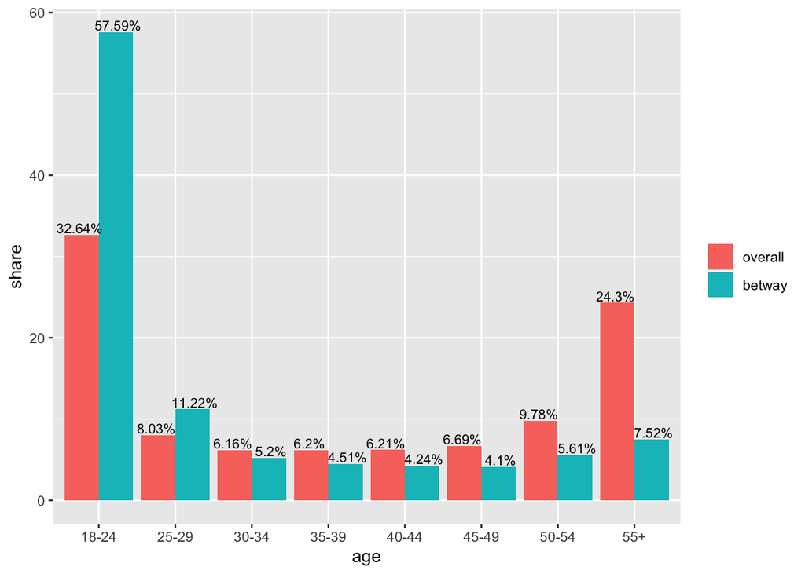

# Ad recognition

## Recognition in general

We asked our participants *Which of the following sports betting brands, if any, have you seen advertised (on TV, online, social media, print, radio, etc.) in the last 4 weeks?*. Participants could select as many competitors as they wanted from a list of brands. Although, they saw only those brands they previously said they *have ever heard of*.

**Germany**  
26% of participants in Germany remember seeing Betway advertisment in the last 4 weeks. The most recognised sports betting brand being advertised among German participants is Tipico (77%).

*Learnings:* Tipico being the official sponsor of Bundesliga and Bwin officially sponsoring 3rd German division, we see a high share of ad recognition among both brands.

| Betway | Tipico | Bwin | Bet365 | Bet at home | Betfair | ODDSET |
| --- | --- | --- | --- | --- | --- | --- |
| 26.14% | 76.52% | 52.06% | 12.88% | 27.36% | 1.91% | 7.09% |

| Bet3000 | Interwetten | Unibet | Betano | Xtip | Mybet | SkyBet |
| --- | --- | --- | --- | --- | --- | --- |
| 6.63% | 14.41% | 5.49% | 2.36% | 5.95% | 5.49% | 16.46% |

**Spain**  
37% of participants in Spain remember seeing Betway advertisment in the last 4 weeks. The most recognised brand being advertised among Spanish participants is Bet365 (72%).

*Learnings:* In Spain Betway resides in the center of the 12 competitors.

| Betway | Bet365 | WilliamHill | Bwin | Sportium | Codere |
| --- | --- | --- | --- | --- | --- |
| 36.96% | 71.68% | 50.72% | 46.08% | 46.24% | 37.44% |

| Betfair | 888 | Luckia | MarcaApuestas | Betsson | MarathonBet |
| --- | --- | --- | --- | --- | --- |
| 32.8% | 44% | 9.44% | 11.2% | 4% | 8.96% |

**UK**  
39% of participants in the UK remember seeing Betway advertisment in the last 4 weeks. The most recognised Brand being advertised among UK participants is Bet365 (74%).

*Learnings:* In the UK market every third participant remembers seeing an ad from Betway.

| Betway | Landbrokes | Bet365 | 888 | Unibet | PaddyPower | WilliamHill |
| --- | --- | --- | --- | --- | --- | --- |
| 38.57% | 65.54% | 74.28% | 44.09% | 14.84% | 70.54% | 61.2% |

| Coral | Betfair | Betfred | BetVictor | Skybet | MoPlay | MarathonBet |
| --- | --- | --- | --- | --- | --- | --- |
| 46% | 43.5% | 38.65% | 25.94% | 62.38% | 4.78% | 7.94% |

## Recognition on the Onefootball platform

In the next step, we asked all participants who said they have seen a brand being advertised in the last four weeks, whether *which of the following brand(s), if any, have you seen advertised on the Onefootball app?* The following table presents the share among those who initially said they have seen the individual brand being advertised.

**Germany**  
7.30% of participants in Germany remember Betway being advertised on the Onefootball app.

*Learnings:* Tipico and Bwin did not run advertising campaigns during the last two years on Onefootball. Yet the omnipresence of both brands spills over to people’s memory of what they saw on the Onefootball platform.

| None | Betway | Tipico | Bwin | Bet365 | Bet at home | Betfair | ODDSET |
| --- | --- | --- | --- | --- | --- | --- | --- |
| 47.89% | 7.29% | 30.84% | 18.63% | 3.08% | 5.62% | 0.44% | 2.72% |

| Bet3000 | Interwetten | Unibet | Betano | Xtip | Mybet | SkyBet |
| --- | --- | --- | --- | --- | --- | --- |
| 1.76% | 1.41% | 0.88% | 0.7% | 0.97% | 0.53% | 4.31% |

**Spain**  
15% of participants in Spain remember Betway being advertised on the Onefootball app.

| None | Betway | Bet365 | WilliamHill | Bwin | Sportium |
| --- | --- | --- | --- | --- | --- |
| 41.7% | 14.76% | 37.08% | 17.34% | 17.71% | 15.31% |

| Codere | Betfair | 888 | Luckia | MarcaApuestas | Betsson | MarathonBet |
| --- | --- | --- | --- | --- | --- | --- |
| 10.52% | 9.23% | 12.36% | 3.14% | 3.69% | 1.85% | 2.4% |

**UK**  
9.3% of participants in the UK remember Betway being advertised on the Onefootball app.

| None | Betway | Ladbrokes | Bet365 | 888 | Unibet | PaddyPower | WilliamHill |
| --- | --- | --- | --- | --- | --- | --- | --- |
| 60.28% | 9.34% | 12.75% | 20.96% | 9.42% | 4.22% | 13.16% | 13.24% |

| Coral | Betfair | Betfred | BetVictor | Skybet | MoPlay | MarathonBet |
| --- | --- | --- | --- | --- | --- | --- |
| 7.72% | 7.31% | 5.77% | 3.82% | 11.86% | 2.44% | 2.68% |

# Brand consideration

We wanted to understand the participants’ consideration for Betway as a betting brand and as their first choice when it comes to placing their next bet. We asked participants *How likely are you to consider the following brands when placing your next sports bet online?*, between *very likely* and *very unlikely*, and we presented only those brands they previously said they have heard of.

## Likeliness for consideration

**Germany**  
We can see that Tipico is the most considered brand for the next bet (62.5% *likely* or *very likely*), followed by Bwin (24%). 13% of participants, who have heard of Betway before, are likely or very likely to consider Betway when placing their next sports bet online.

**Methodology:** Every column is calculated separately considering only those who previously said they recognise the brand.

| Scale | Betway | Tipico | Bwin | Bet365 | Bet.at.home | Betfair | ODDSET | Bet3000 | Interwetten | Unibet | Betano | Xtip | Mybet | Skybet |
| --- | --- | --- | --- | --- | --- | --- | --- | --- | --- | --- | --- | --- | --- | --- |
| very likely | 4.44% | 45.77% | 13.15% | 8.32% | 2.58% | 2.2% | 5.54% | 5.74% | 3.42% | 0.78% | 4.67% | 8.19% | 1.13% | 5.99% |
| likely | 8.42% | 16.71% | 10.67% | 7.88% | 3.95% | 3.3% | 8.03% | 6.01% | 4.11% | 1.3% | 3.33% | 5.8% | 1.13% | 8.2% |
| neither | 7.81% | 6.36% | 8.73% | 8.32% | 9.42% | 8.24% | 8.6% | 8.88% | 8.68% | 10.13% | 8% | 11.26% | 9.07% | 12.64% |
| unlikely | 11.49% | 6.17% | 13.15% | 13.57% | 11.7% | 10.99% | 13.19% | 11.23% | 13.24% | 11.43% | 10.67% | 11.95% | 11.9% | 10.64% |
| very unlikely | 67.84% | 24.98% | 54.31% | 61.93% | 72.34% | 75.27% | 64.63% | 68.15% | 70.55% | 76.36% | 73.33% | 62.8% | 76.77% | 62.53% |

**Spain**  
Bet365 is the most considered brand for the next online sport bet among Spanish participants (54% *likely* or *very likely*), followed by Sportium (48%) and Codere (47%). 34% of participants in Spain, who have heard of Betway before, are likely or very likely to consider Betway when placing their next sports bet online.

| Scale | Betway | Bet365 | WilliamHill | Bwin | Sportium | Codere | Betfair | x888 | Luckia | MarcaApuestas | Betsson | MarathonBet |
| --- | --- | --- | --- | --- | --- | --- | --- | --- | --- | --- | --- | --- |
| very likely | 20.21% | 33.18% | 21.76% | 19.37% | 27.15% | 26.2% | 13.48% | 14.53% | 22.92% | 21.99% | 27.87% | 16.36% |
| likely | 14.04% | 21.16% | 17.65% | 12.82% | 21.05% | 21.41% | 14.54% | 14.53% | 13.19% | 12.06% | 13.11% | 10.91% |
| neither | 19.18% | 15.37% | 16.47% | 21.65% | 16.9% | 14.7% | 21.99% | 19.26% | 18.06% | 17.02% | 9.84% | 12.73% |
| unlikely | 16.1% | 9.35% | 14.71% | 15.67% | 11.08% | 12.78% | 15.96% | 15.54% | 13.89% | 12.77% | 13.11% | 16.36% |
| very unlikely | 30.48% | 20.94% | 29.41% | 30.48% | 23.82% | 24.92% | 34.04% | 36.15% | 31.94% | 36.17% | 36.07% | 43.64% |

**UK**  
Skybet is the most considered brand for the next online sport bet among UK participants (55% *likely* or *very likely*), followed by Bet365 (44%). 21% of participants in the UK, who have heard of Betway before, are likely or very likely to consider Betway when placing their next sports bet online.

| Scale | Betway | Ladbrokes | Bet365 | x888 | Unibet | PaddyPower | WilliamHill | Coral | Betfair | Betfred | BetVictor | Skybet | MoPlay | MarathonBet |
| --- | --- | --- | --- | --- | --- | --- | --- | --- | --- | --- | --- | --- | --- | --- |
| very likely | 13.14% | 17.57% | 26.56% | 10% | 12.02% | 17.33% | 17.32% | 11.2% | 14.09% | 10.72% | 8.95% | 36.26% | 30.4% | 18.71% |
| likely | 8.26% | 13.42% | 17.33% | 5.23% | 4.07% | 13.26% | 14.97% | 10.11% | 10.81% | 8.07% | 4.83% | 18.71% | 4% | 4.68% |
| neither | 18.14% | 19.79% | 16.22% | 20.23% | 16.9% | 21.2% | 20.55% | 22.61% | 20.13% | 18.37% | 18.75% | 15.69% | 12.8% | 11.51% |
| unlikely | 16.05% | 14.48% | 12.4% | 18.41% | 17.52% | 13.46% | 12.72% | 16.3% | 16.21% | 16.99% | 17.9% | 8.28% | 10.4% | 15.47% |
| very unlikely | 44.42% | 34.75% | 27.49% | 46.14% | 49.49% | 34.75% | 34.44% | 39.78% | 38.77% | 45.86% | 49.57% | 21.05% | 42.4% | 49.64% |

## First choice brand

From all the brands that a user considered *likely* or *very likely*, we asked which of these *would you say is your first-choice brand when placing a sports bet online*.

**Germany**  
Overall in Germany, the brand which got selected most often as *first-choice brand* is Tipico (68%), followed by Bwin (13%). 3% of all German participants select Betway as their first-choice brand.

**Learnings:** The plot shows that with 2.66% Betway is amongst the Top 6 first choice brands of participants. Nevertheless Tipico leads with a substantial margin.

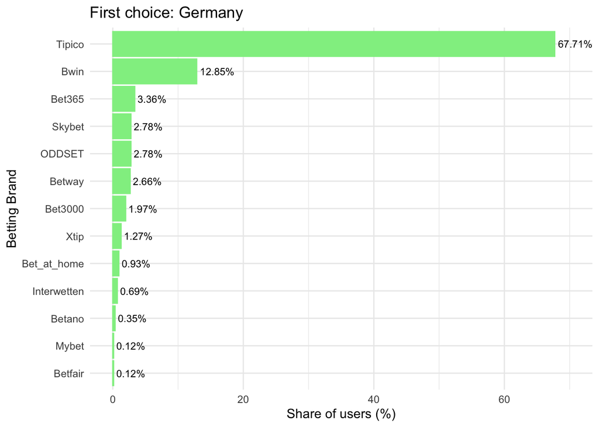

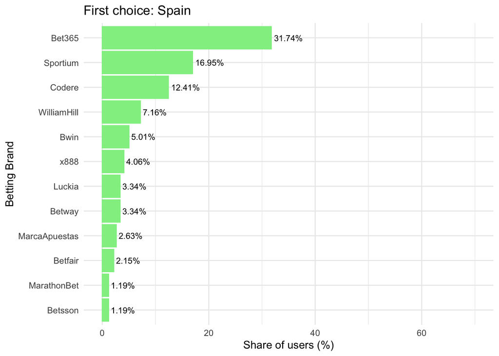

**Learnings:** In the UK the user share shows a more diverse distribution. Betway is with 2.2% in the center of the 14 competitors.

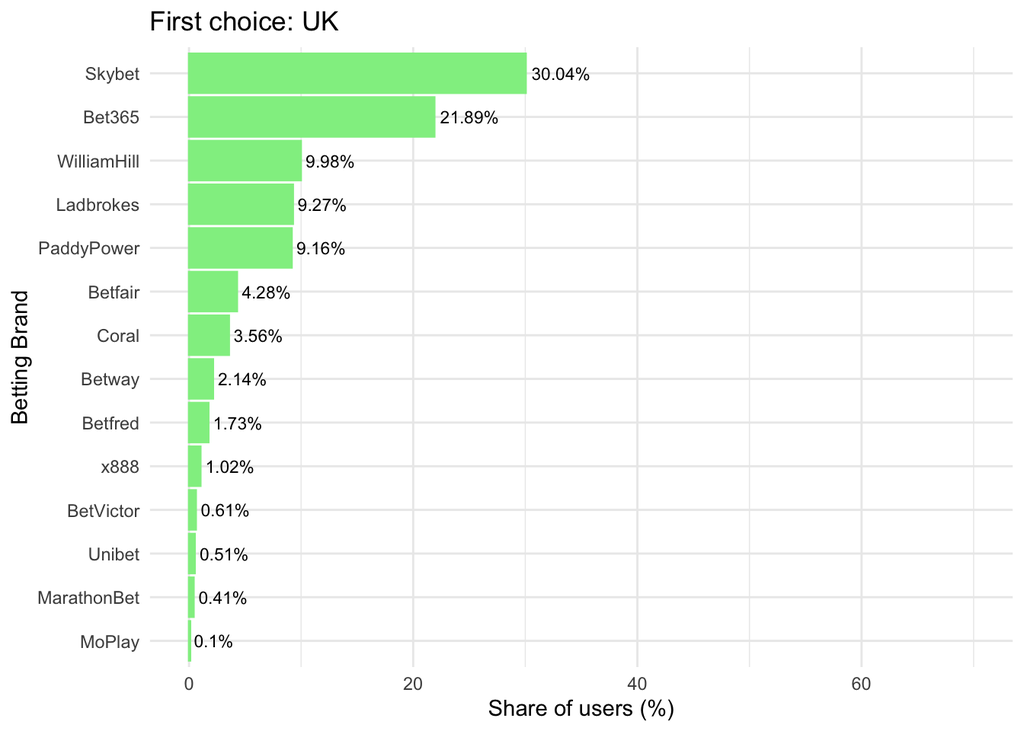

## Appeal of Promotions

We wanted to understand *Which types of promotions/offers appeal to you most when deciding which betting brand to use?*. The participants could select as many options as they wanted. We can see that in Germany, **Enhanced Odds** and **Early Payouts** are most appealing, while Spanish users care more interested in **Money back** and **Get and Bet** options. UK users are most interested in **Enhanced Odds** and **Money back**.

| market | Money back | Enhanced Odds | Bet & Get | Bet builder | Early Payouts | None |
| --- | --- | --- | --- | --- | --- | --- |
| Germany | 43.71% | 56.29% | 49.64% | 19.95% | 54.16% | 11.64% |
| Spain | 48.39% | 42.74% | 45.97% | 26.61% | 29.84% | 8.87% |
| UK | 54.45% | 59% | 36.88% | 34.06% | 49.67% | 11.06% |

# Usage

After looking at awareness and consideration, we will now start exploring the actual usage of Betway and its competition among our participants.

## Online vs Shop

We asked our participants, which of the following brands they have ever used, based on their previous answers on *which of the brands have you heard of?* The following percentages are all based on all those who have heard of a given brand.

**Germany**  
We can see that for German participants, 12% of those who have heard of Betway have used it online. For Tipico, the share is 68% and 33% for Bwin.

| Scale | Betway | Tipico | Bwin | Bet365 | Bet.at.home | Betfair | ODDSET | Bet3000 | Interwetten | Unibet | Betano | Xtip | Mybet | Skybet |
| --- | --- | --- | --- | --- | --- | --- | --- | --- | --- | --- | --- | --- | --- | --- |
| Online | 11.95% | 68.31% | 33.43% | 22.22% | 10.59% | 7.1% | 5.83% | 11.15% | 7.63% | 4.69% | 9.6% | 5.95% | 3.51% | 13.42% |
| Shop | 3.66% | 15.14% | 4.22% | 3.44% | 2.46% | 2.58% | 25.36% | 11.46% | 2.18% | 1.56% | 0.8% | 20.63% | 4.91% | 2.19% |
| Neither | 84.39% | 16.56% | 62.35% | 74.34% | 86.96% | 90.32% | 68.8% | 77.4% | 90.19% | 93.75% | 89.6% | 73.41% | 91.58% | 84.38% |

**Spain**  
28% of Spanish participants who have heard of Betway have used it online. Bet365 has the highest score on this scale with 52% awareness.

| Scale | Betway | Bet365 | WilliamHill | Bwin | Sportium | Codere | Betfair | x888 | Luckia | MarcaApuestas | Betsson | MarathonBet |
| --- | --- | --- | --- | --- | --- | --- | --- | --- | --- | --- | --- | --- |
| Online | 28.1% | 51.82% | 34.17% | 33.47% | 21.88% | 20% | 25.37% | 25.85% | 22.13% | 33% | 28.85% | 17.86% |
| Shop | 8.1% | 10.89% | 4.58% | 8.87% | 46.09% | 40.89% | 4.48% | 6.34% | 35.25% | 8% | 11.54% | 13.1% |
| Neither | 63.81% | 37.29% | 61.25% | 57.66% | 32.03% | 39.11% | 70.15% | 67.8% | 42.62% | 59% | 59.62% | 69.05% |

**UK**  
20% of participants in the UK who have heard of Betway have used it online. In this market, Skybet (66%) and Bet365 (54%) perform best on this scale.

| Scale | Betway | Ladbrokes | Bet365 | x888 | Unibet | PaddyPower | WilliamHill | Coral | Betfair | Betfred | BetVictor | Skybet | MoPlay | MarathonBet |
| --- | --- | --- | --- | --- | --- | --- | --- | --- | --- | --- | --- | --- | --- | --- |
| Online | 20.27% | 31.81% | 53.99% | 20.18% | 15.72% | 41.57% | 34.44% | 24.32% | 29.36% | 18.01% | 18.32% | 65.78% | 39.33% | 17.76% |
| Shop | 5.45% | 28.14% | 5.15% | 3.14% | 5.15% | 8.11% | 24.71% | 23.03% | 3.46% | 13.57% | 3.11% | 3.44% | 6.74% | 5.61% |
| Neither | 74.28% | 40.05% | 40.86% | 76.68% | 79.13% | 50.32% | 40.85% | 52.65% | 67.17% | 68.42% | 78.57% | 30.79% | 53.93% | 76.64% |

## Main account

We wanted to understand which brand our participants select as their main account.

**Methodology:** The missing % to 100% said they do not have a main account.

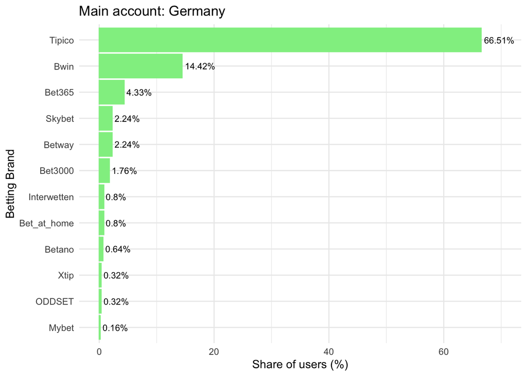

**Learnings:** Betway is among the top 5 platforms in Germany, participants consider as their main accounts.

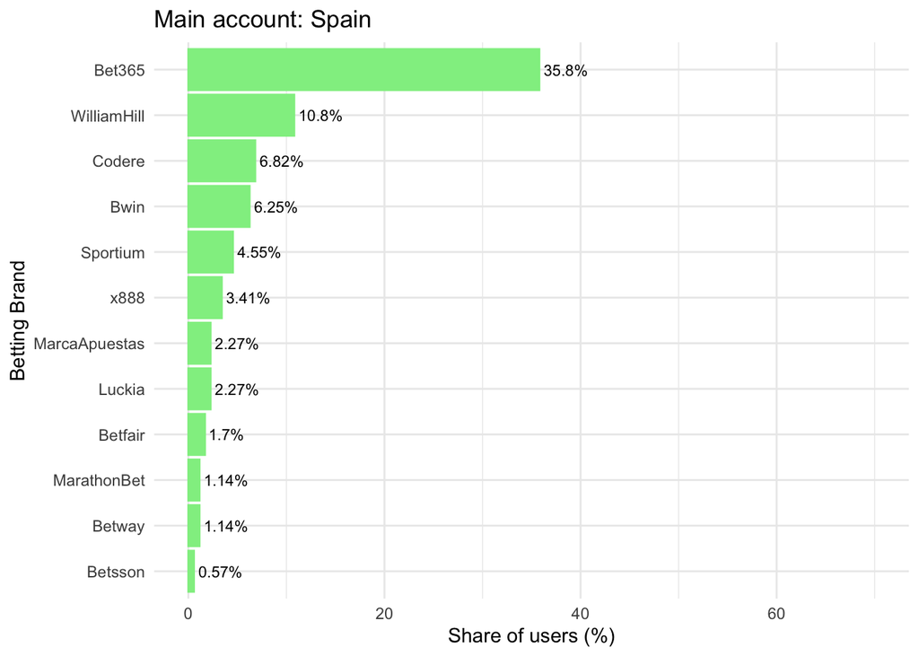

**Learnings:** Betway shares the 4th place for “Main account” together with Skybet in Germany.

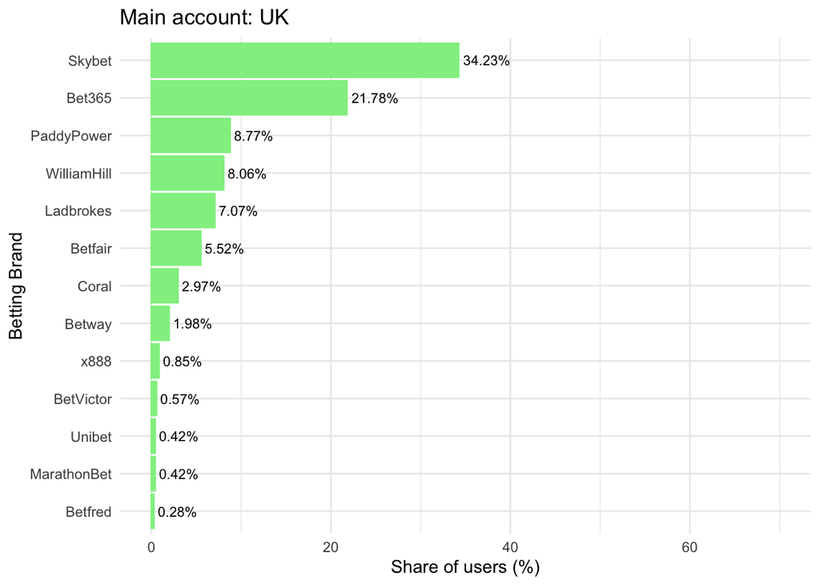

**Learnings:** In Spain the amount of participants who chose Betway as their main account is at 1.2%.

# Likelihood of Recommendation

We asked our users *How likely would you recommend the following brands to friends or family?* and measured the answer on a 0 (*Not likely at all*) to 10 (*Very likely*) scale. In Germany, the average score for Betway is 5.59, in Spain 6.79 and in the UK 5.9.

**Methodology:** Participants only saw those brands they previously said they recognise.

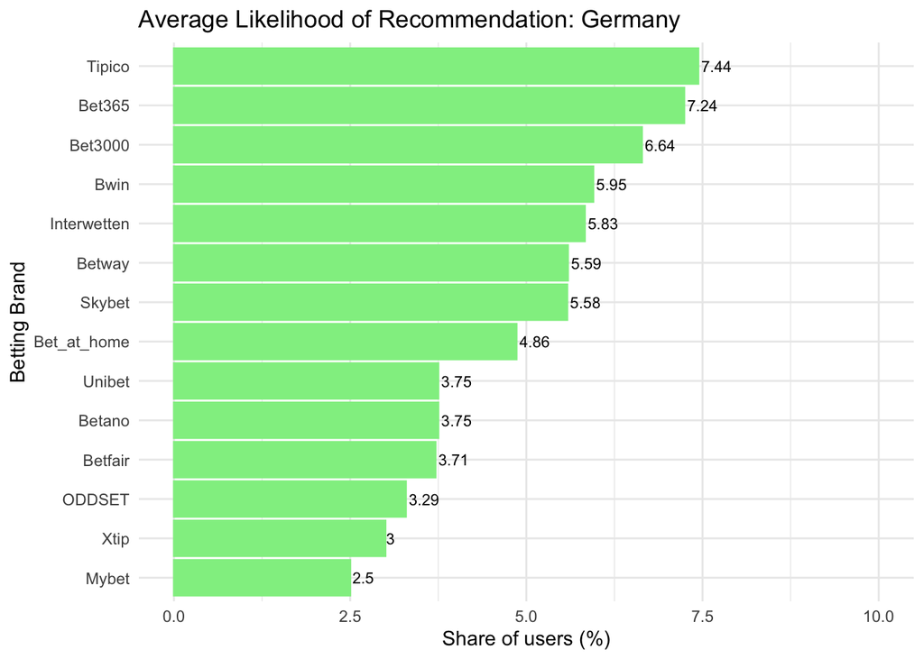

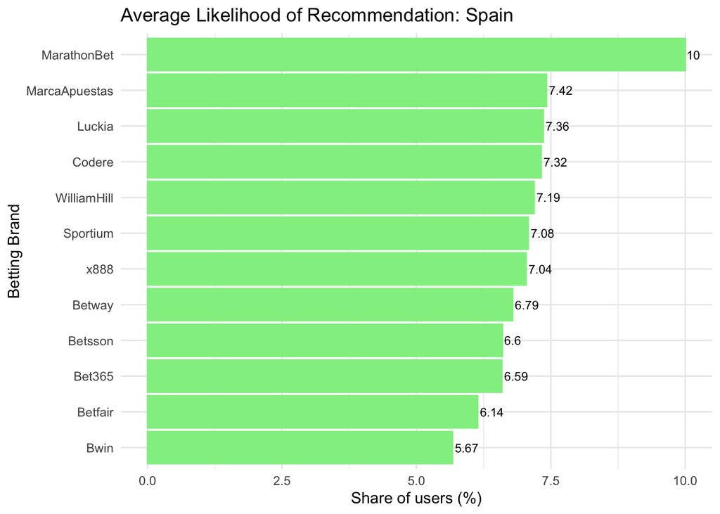

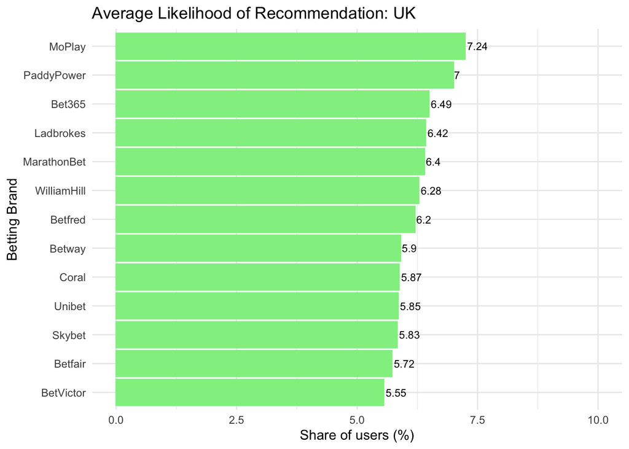

# Sports to bet on

We asked our participants, which kind of sports they bet on.

**Germany:**  
Besides Football (99%), American Football and Basketball are the most popular sports for betting among our Onefootball audience.

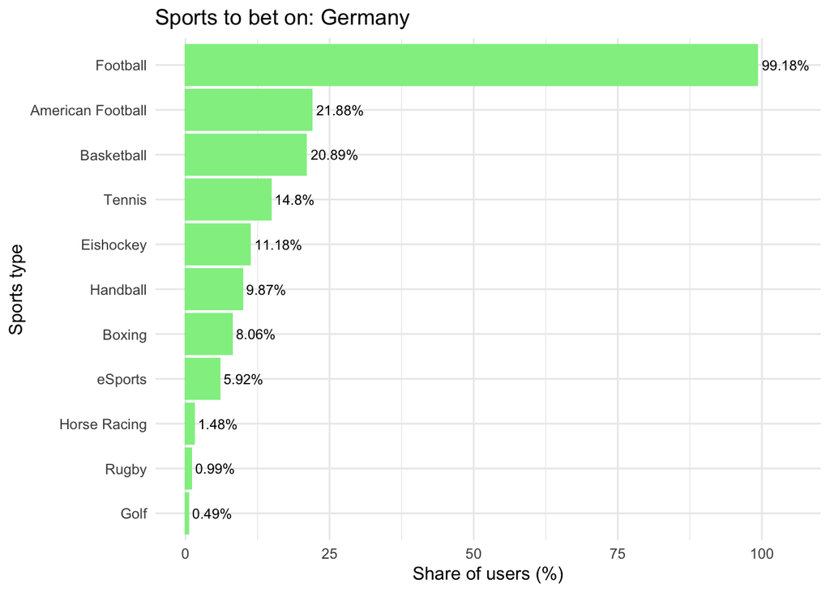

**Spain:**  
Besides Football (98%), Basketball and Tennis are the most popular sports for betting among our Onefootball audience.

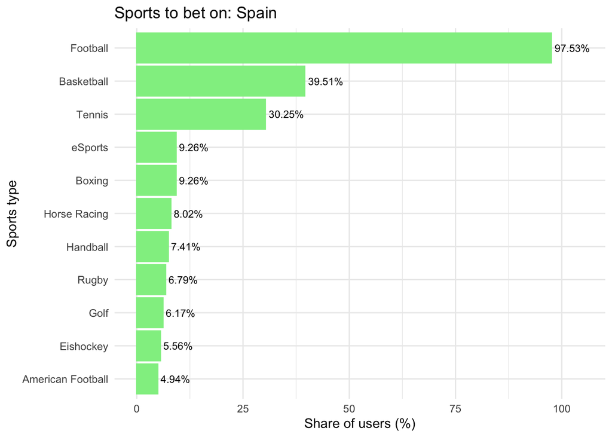

**UK:**  
Besides Football (99%), Boxing and Horse Racing are the most popular sports for betting among our Onefootball audience.

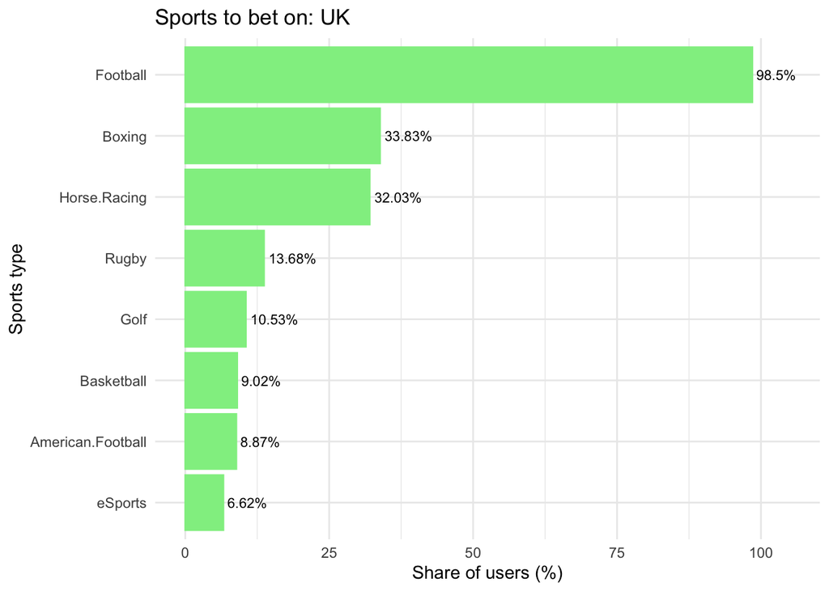

# Brand Characteristics

For those who are familiar with Betway as a brand, we asked different questions about their brand perception in form of statements between 1 (*Strongly disagree*) and 5 (*Strongly agree*). An average above 3 indicates overall agreement with the statement.

**Learnings:** In this part of the survey we can take a closer look at what areas are stronger then others.

| statements | Germany | Spain | UK |
| --- | --- | --- | --- |
| Betway is a brand I trust | 2.63 | 3.18 | 2.99 |
| Betway offers attractive odds | 2.77 | 3.14 | 2.93 |
| Betway offers good promotions. | 2.74 | 3.11 | 2.92 |
| Betway is a well-known brand. | 3.10 | 3.56 | 3.26 |
| Betway supports responsible gambling. | 2.71 | 3.34 | 3.15 |
| Betway has easy to use online or app service. | 2.80 | 3.38 | 3.11 |
| Betway adds excitement to watching sports. | 2.72 | 3.10 | 2.96 |
| Betway allows me to prove my sporting knowledge to others | 2.51 | 3.07 | 2.83 |
| Betway emphasises the social side of betting with friends. | 2.50 | 2.98 | 2.82 |
| Betway is an entertaining brand. | 2.62 | 3.20 | 2.88 |
| Betway is a brand my friends use. | 2.19 | 2.88 | 2.74 |
| Betway has wide range of online betting markets. | 2.86 | 3.39 | 3.13 |
| Betway offers different and innovative ways to bet. | 2.79 | 3.20 | 2.89 |
| Betway is associated with high level sports. | 2.80 | 3.54 | 3.07 |
| Betway has good customer service. | 2.70 | 3.19 | 2.95 |

## Benchmark for future brand development

We wanted to understand what a realistic benchmark would be in terms of betting brand characteristics. Therefore, we looked only at the most named *main accounts* per market and analysed the ratings on the same brand statements as above.

| statements | Tipico (DE) | Bet365 (SP) | Skybet (UK) |
| --- | --- | --- | --- |
| Sample Size: | 415.00 | 63.00 | 242.00 |
| […] is a brand I trust | 4.50 | 4.63 | 4.35 |
| […] offers attractive odds | 4.07 | 4.32 | 4.59 |
| […] offers good promotions. | 4.04 | 3.98 | 4.22 |
| […] is a well-known brand. | 4.79 | 4.44 | 3.70 |
| […] supports responsible gambling. | 3.59 | 4.24 | 3.65 |
| […] has easy to use online or app service. | 4.51 | 4.39 | 4.10 |
| […] adds excitement to watching sports. | 4.12 | 4.29 | 4.30 |
| […] allows me to prove my sporting knowledge to others | 3.40 | 3.98 | 4.28 |
| […] emphasises the social side of betting with friends. | 3.24 | 3.46 | 3.94 |
| […] is an entertaining brand. | 4.17 | 4.24 | 4.40 |
| […] is a brand my friends use. | 4.35 | 4.10 | 4.01 |
| […] has wide range of online betting markets. | 4.36 | 4.24 | 1.00 |
| […] offers different and innovative ways to bet. | 4.06 | 3.95 | 2.00 |
| […] is associated with high level sports. | 4.28 | 4.17 | 3.00 |
| […] has good customer service. | 3.60 | 4.34 | 4.00 |

# Conclusion and next steps

Overall, the Betway User Survey has been a great success. The collaboration between both teams returned valuable results, that will shape future strategies and provide an origin for upcoming surveys. In Germany, Spain and the UK we have collected valuable learnings and insights regarding the Betway brand, to better understand the respective markets but also the competitors that Betway is facing in those markets.

Another interesting learning is that the overall age distribution is significantly older than the age distribution of the participants that heard of Betway. The majority of people who know Betway is under 30 years old.

We have learned that Betway has a rather high brand recognition amongst Onefootball users, with about 50% to 70%. Surprisingly this places Betway amongst the Top 3 recognized brands in Germany. Taking a closer look at the recognition on the Onefootball platform we can observe that Tipico and Bwin have a high recognition although no ads were served in the last 2 years. Nevertheless, Betway claims the 3rd place in recognized ads on the Onefootball platform with almost 8% compared to other betting advertisers like Unibet that have 1%.

The overall market situation in the respective countries gets more apparent when looking at the “first choice brand”. Here we can find that in each market there is a well-situated market leader. Therefore the focus should rather lay on competing with the 2nd and 3rd biggest brands in these countries. Overall, Betway is in the center of the provided competitors with a small margin.